# Week 6 Exercises and Notes

Mitchell

May 25, 2020

### Dull 560 Luc Data

Next, let’s work with my Dull560 luciferase assay dataset. Let’s load in the data and make sure that everything is peachy. We just need to copy-paste what we had from Week 4.

```r
library(tidyverse)
Luc_data <- read_csv("Dull 560_All_Results.csv")
#We could parse some of the data a bit better.
Luc_data$Genotype <- parse_factor(Luc_data$Genotype)

summary(Luc_data$Genotype)
```

```
##         col 8x T2 95.01 8x T2 97.30 8x T2 96.14
##          44         164          19           1
```

```r
names <- tribble(
  ~Genotype,  ~true_genotype,
    "col",         "wt",
    "8x T2 95.01",  "95.01",
    "8x T2 97.30",  "97.30",
    "8x T2 96.14",  "96.14"
  )

Luc_data_compact <- Luc_data %>%
  left_join(names, by = "Genotype") %>%
  select(Region:RAE, true_genotype)
Luc_data_compact$Genotype <- parse_factor(Luc_data_compact$Genotype)
Luc_data_compact$true_genotype <- parse_factor(Luc_data_compact$true_genotype)

Luc_data2 <- Luc_data %>%
  left_join(names, by = "Genotype") %>%
  select(Region:RAE, true_genotype, '36':'176')
Luc_data2$Genotype <- parse_factor(Luc_data2$Genotype)
Luc_data2$true_genotype <- parse_factor(Luc_data2$true_genotype)

head(Luc_data2)
```

```
## # A tibble: 6 x 78
##   Region Genotype Period Amplitude  Phase   RAE true_genotype   `36`   `38`
##    <dbl> <fct>     <dbl>     <dbl>  <dbl> <dbl> <fct>          <dbl>  <dbl>
## 1    119 col        25.5     1087   10.4   0.23 wt            6.77e4 6.78e4
## 2    325 col        25.7      748.  11.5   0.23 wt            6.64e4 6.71e4
## 3    167 col        25.8     1355    9.56  0.25 wt            9.08e4 9.31e4
## 4     73 col        24.1     1853    7.49  0.27 wt            1.12e5 1.12e5
## 5    320 col        24.3     1224    9.2   0.28 wt            8.97e4 8.98e4
## 6     71 col        26.0      896. -12.7   0.31 wt            9.89e4 9.76e4
## # ... with 69 more variables: `40` <dbl>, `42` <dbl>, `44` <dbl>, `46` <dbl>,
## #   `48` <dbl>, `50` <dbl>, `52` <dbl>, `54` <dbl>, `56` <dbl>, `58` <dbl>,
## #   `60` <dbl>, `62` <dbl>, `64` <dbl>, `66` <dbl>, `68` <dbl>, `70` <dbl>,
## #   `72` <dbl>, `74` <dbl>, `76` <dbl>, `78` <dbl>, `80` <dbl>, `82` <dbl>,
## #   `84` <dbl>, `86` <dbl>, `88` <dbl>, `90` <dbl>, `92` <dbl>, `94` <dbl>,
## #   `96` <dbl>, `98` <dbl>, `100` <dbl>, `102` <dbl>, `104` <dbl>, `106` <dbl>,
## #   `108` <dbl>, `110` <dbl>, `112` <dbl>, `114` <dbl>, `116` <dbl>,
## #   `118` <dbl>, `120` <dbl>, `122` <dbl>, `124` <dbl>, `126` <dbl>,
## #   `128` <dbl>, `130` <dbl>, `132` <dbl>, `134` <dbl>, `136` <dbl>,
## #   `138` <dbl>, `140` <dbl>, `142` <dbl>, `144` <dbl>, `146` <dbl>,
## #   `148` <dbl>, `150` <dbl>, `152` <dbl>, `154` <dbl>, `156` <dbl>,
## #   `158` <dbl>, `160` <dbl>, `162` <dbl>, `164` <dbl>, `166` <dbl>,
## #   `168` <dbl>, `170` <dbl>, `172` <dbl>, `174` <dbl>, `176` <dbl>
```

```r
summary(Luc_data2)
```

```
##      Region              Genotype       Period        Amplitude
##  Min.   :  1.00   col        : 44   Min.   :15.00   Min.   :  157.3
##  1st Qu.: 74.75   8x T2 95.01:164   1st Qu.:22.21   1st Qu.: 2741.8
##  Median :159.00   8x T2 97.30: 19   Median :25.73   Median : 7806.0
##  Mean   :157.64   8x T2 96.14:  1   Mean   :25.31   Mean   : 8992.2
##  3rd Qu.:237.50                     3rd Qu.:28.75   3rd Qu.:12997.5
##  Max.   :326.00                     Max.   :34.93   Max.   :34170.0
##      Phase               RAE         true_genotype       36
##  Min.   :-16.1100   Min.   :0.2300   wt   : 44     Min.   : 64835
##  1st Qu.: -5.5225   1st Qu.:0.5775   95.01:164     1st Qu.:191721
##  Median :  0.0650   Median :0.7400   97.30: 19     Median :332807
##  Mean   :  0.3175   Mean   :0.7035   96.14:  1     Mean   :352854
##  3rd Qu.:  7.2475   3rd Qu.:0.8400                 3rd Qu.:508824
##  Max.   : 14.8800   Max.   :1.0000                 Max.   :923386
##        38               40               42               44
##  Min.   : 64800   Min.   : 64970   Min.   : 65109   Min.   : 64711
##  1st Qu.:187470   1st Qu.:185310   1st Qu.:189318   1st Qu.:189495
##  Median :326738   Median :332865   Median :336502   Median :338623
##  Mean   :348810   Mean   :352727   Mean   :359216   Mean   :363503
##  3rd Qu.:501939   3rd Qu.:505098   3rd Qu.:521319   3rd Qu.:530956
##  Max.   :925799   Max.   :930300   Max.   :956893   Max.   :974121
##        46               48               50               52
##  Min.   : 65184   Min.   : 64809   Min.   : 65059   Min.   : 64903
##  1st Qu.:191871   1st Qu.:192516   1st Qu.:189825   1st Qu.:188596
##  Median :337505   Median :341905   Median :339742   Median :334438
##  Mean   :362378   Mean   :358839   Mean   :354731   Mean   :351086
##  3rd Qu.:528406   3rd Qu.:521747   3rd Qu.:514852   3rd Qu.:505645
##  Max.   :999917   Max.   :947913   Max.   :924359   Max.   :904619
##        54               56               58               60
##  Min.   : 64545   Min.   : 65228   Min.   : 65249   Min.   : 64784
##  1st Qu.:186720   1st Qu.:190394   1st Qu.:193408   1st Qu.:193145
##  Median :336305   Median :343152   Median :340348   Median :343268
##  Mean   :352330   Mean   :356221   Mean   :359488   Mean   :361207
##  3rd Qu.:506271   3rd Qu.:516980   3rd Qu.:530209   3rd Qu.:528219
##  Max.   :908097   Max.   :937127   Max.   :975458   Max.   :986085
##        62               64               66               68
##  Min.   : 64800   Min.   : 64799   Min.   : 65391   Min.   : 64661
##  1st Qu.:191138   1st Qu.:188638   1st Qu.:193104   1st Qu.:190506
##  Median :336600   Median :328072   Median :332405   Median :336815
##  Mean   :361479   Mean   :358655   Mean   :358114   Mean   :359587
```

[output cut: 85 more lines]

```
##  Max.   :989214   Max.   :1002423   Max.   :982154   Max.   :946127
##       166              168              170              172
##  Min.   : 65073   Min.   : 64983   Min.   : 64410   Min.   : 65216
##  1st Qu.:190662   1st Qu.:191409   1st Qu.:187806   1st Qu.:191112
##  Median :335167   Median :334917   Median :339370   Median :342856
##  Mean   :356260   Mean   :357327   Mean   :357112   Mean   :357330
##  3rd Qu.:521140   3rd Qu.:519075   3rd Qu.:512658   3rd Qu.:519482
##  Max.   :928298   Max.   :916271   Max.   :909370   Max.   :918152
##       174              176
##  Min.   : 65326   Min.   : 64765
##  1st Qu.:190253   1st Qu.:186441
##  Median :341027   Median :326113
##  Mean   :357760   Mean   :361762
##  3rd Qu.:529025   3rd Qu.:523673
##  Max.   :941314   Max.   :979464
```

```r
#Let's take the chance to also set the colors we want.
colors <- c("wt" = "#D55E00",
            "95.01" = "#0072B2",
            "97.30" = "#CC79A7",
            "96.14" = "#009E73")
```

Now, let’s make a function that does what we want. What we need to accomplish: Input is a data frame (for a particular genotype) 1. Compute the mean luminescence at each ZT time, save in new df 2. Compute the standard deviation of each ZT time, save in new df 3. Rearrange each df using `pivot_longer` 4. Paste the data frames together

```r
luminescence_graph <- function(x, genotype = "genotype") {

genotype <- genotype #Don't know why, this somehow makes the whole thing work better.

interim <- x %>%
  filter(true_genotype == (!! genotype)) %>%
  select('36':'176')                     #Filter our supplied dataset according to the genotype we specify, remove useless columnes

times <- seq(from = 36, to = 176, by = 2)
times <- tibble(times)                  #Create a dataset with the appropriate times for later.

stdev_interim <- interim %>%
  map_dbl(sd)
sd_output <- tibble(stdev_interim) %>%
  bind_cols(times, .)                  #Calculate SD of luminescence for each ZT time, bind times:

means_interim <- interim %>%
  map_dbl(mean)
final_output <- tibble(means_interim) %>%
  bind_cols(times, .) %>%             #Calculate means of luminescence for each ZT time, bind times:
  left_join(sd_output, by = "times") %>%
  rename(ZT = times, lum = means_interim, lum_sd = stdev_interim ) %>% #Join means and sd together, rename columns.
  mutate(lum_se = lum_sd/lum,
         lum_scaled = (lum-min(lum))/(max(lum)-min(lum)))
print(final_output)

ggplot(final_output, aes(ZT, lum_scaled)) +
  geom_point(size = 2.5, color = "#0072B2") +
  theme_bw() +
  theme(plot.title = element_text(hjust = 0.5)) +
  labs(x = "ZT time (hours)",
       y = "Scaled luminescence values") +
  geom_errorbar(aes(ymin = lum_scaled - lum_se, ymax = lum_scaled + lum_se), color = "#0072B2") +
  coord_cartesian(xlim = c(36, 176), ylim = c(-0.5, 1.5)) +
  scale_y_continuous(breaks = seq(from = -0.5, to = 1.5, by = 0.2)) +
  scale_x_continuous(breaks = seq(from = 36, to = 176, by = 20))

}
```

OK, let’s try it out:

```
## # A tibble: 71 x 5
##       ZT    lum lum_sd lum_se lum_scaled
##    <dbl>  <dbl>  <dbl>  <dbl>      <dbl>
##  1    36 79009. 13168.  0.167     0.467
##  2    38 79130. 12886.  0.163     0.542
##  3    40 79454. 13043.  0.164     0.744
##  4    42 79498. 13248.  0.167     0.771
##  5    44 79436. 13313.  0.168     0.732
##  6    46 79431. 13315.  0.168     0.729
##  7    48 79103. 13232.  0.167     0.525
##  8    50 78534. 12879.  0.164     0.171
##  9    52 78258. 12709.  0.162     0
## 10    54 78294. 13016.  0.166     0.0219
## # ... with 61 more rows
```

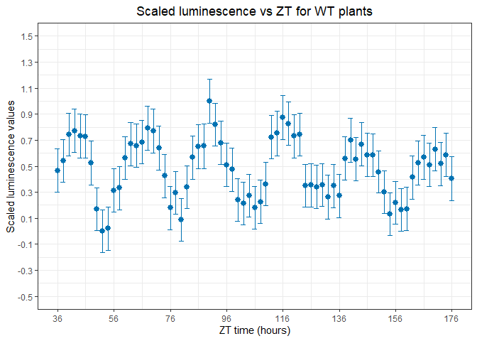

```r
luminescence_graph(Luc_data2, genotype = "wt") + labs(title = "Scaled luminescence vs ZT for WT plants")
```

```
## # A tibble: 71 x 5
##       ZT     lum  lum_sd lum_se lum_scaled
##    <dbl>   <dbl>   <dbl>  <dbl>      <dbl>
##  1    36 439930. 177305.  0.403      0.261
##  2    38 434497. 176225.  0.406      0
##  3    40 440297. 179942.  0.409      0.279
##  4    42 449409. 185288.  0.412      0.717
##  5    44 455283. 189951.  0.417      1
##  6    46 453961. 187584.  0.413      0.936
##  7    48 448925. 184266.  0.410      0.694
##  8    50 443605. 181388.  0.409      0.438
##  9    52 438875. 180160.  0.411      0.211
## 10    54 440565. 180974.  0.411      0.292
## # ... with 61 more rows
```

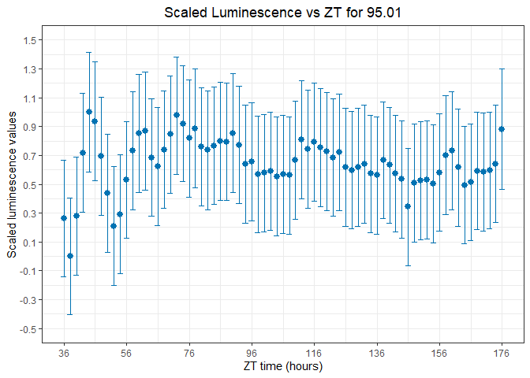

```r
luminescence_graph(Luc_data2, genotype = "95.01") + labs(title = "Scaled Luminescence vs ZT for 95.01")
```

```
## # A tibble: 71 x 5
##       ZT     lum lum_sd lum_se lum_scaled
##    <dbl>   <dbl>  <dbl>  <dbl>      <dbl>
##  1    36 245005. 84893.  0.346      0.850
##  2    38 243012. 84935.  0.350      0.717
##  3    40 239162. 83252.  0.348      0.460
##  4    42 238332. 84035.  0.353      0.404
##  5    44 239334. 83043.  0.347      0.471
##  6    46 237339. 81863.  0.345      0.338
##  7    48 239131. 84344.  0.353      0.458
##  8    50 237234. 83449.  0.352      0.331
##  9    52 234997. 79600.  0.339      0.181
## 10    54 235128. 80310.  0.342      0.190
## # ... with 61 more rows
```

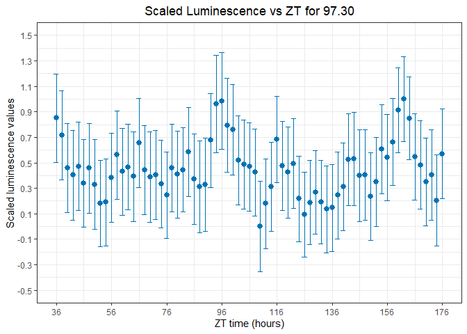

```r
luminescence_graph(Luc_data2, genotype = "97.30") + labs(title = "Scaled Luminescence vs ZT for 97.30")
```

```
## # A tibble: 71 x 5
##       ZT   lum lum_sd lum_se lum_scaled
##    <dbl> <dbl>  <dbl>  <dbl>      <dbl>
##  1    36   NaN     NA     NA        NaN
##  2    38   NaN     NA     NA        NaN
##  3    40   NaN     NA     NA        NaN
##  4    42   NaN     NA     NA        NaN
##  5    44   NaN     NA     NA        NaN
##  6    46   NaN     NA     NA        NaN
##  7    48   NaN     NA     NA        NaN
##  8    50   NaN     NA     NA        NaN
##  9    52   NaN     NA     NA        NaN
## 10    54   NaN     NA     NA        NaN
## # ... with 61 more rows
```

[figure not shown]

```r
luminescence_graph(Luc_data2, genotype = "96.13") + labs(title = "Scaled Luminescence vs ZT for 96.13")
```

### Stats Videos

#### ANOVA in R

```r
DietData <- read_csv("DietWeightLoss.csv")
```

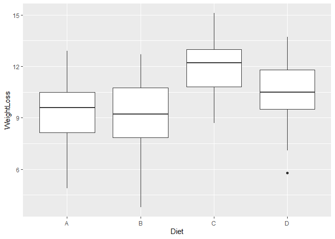

```r
attach(DietData)
ggplot(DietData, aes(Diet, WeightLoss)) +
  geom_boxplot()
```

`aov` let’s us perform ANOVA. H0: Mean weight loss the same for all diets.

```r
(ANOVA1 <- aov(WeightLoss ~ Diet))
```

```
## Call:
##    aov(formula = WeightLoss ~ Diet)
##
## Terms:
##                      Diet Residuals
## Sum of Squares   97.32983 296.98667
## Deg. of Freedom         3        56
##
## Residual standard error: 2.302897
## Estimated effects may be unbalanced
```

We can get a better result using `summary`. Examine and pull out stuff using `attributes`.

```r
summary(ANOVA1)
```

```
##             Df Sum Sq Mean Sq F value  Pr(>F)
## Diet         3  97.33   32.44   6.118 0.00113 **
## Residuals   56 296.99    5.30
## ---
## Signif. codes:  0 '***' 0.001 '**' 0.01 '*' 0.05 '.' 0.1 ' ' 1
```

```r
attributes(ANOVA1)
```

```
## $names
##  [1] "coefficients"  "residuals"     "effects"       "rank"
##  [5] "fitted.values" "assign"        "qr"            "df.residual"
##  [9] "contrasts"     "xlevels"       "call"          "terms"
## [13] "model"
##
## $class
## [1] "aov" "lm"
```

```r
ANOVA1$coefficients
```

```
## (Intercept)       DietB       DietC       DietD
##   9.1800000  -0.2733333   2.9333333   1.3600000
```

Conclusion: at least one of the sample means is different. But which one(s) is different? We could use the `TukeyHSD`command to investigate further. Adjusted p value is on the right. We could also plot the result using `plot`.

```r
TukeyHSD(ANOVA1)
```

```
##   Tukey multiple comparisons of means
##     95% family-wise confidence level
##
## Fit: aov(formula = WeightLoss ~ Diet)
##
## $Diet
##           diff        lwr       upr     p adj
## B-A -0.2733333 -2.4999391 1.9532725 0.9880087
## C-A  2.9333333  0.7067275 5.1599391 0.0051336
## D-A  1.3600000 -0.8666058 3.5866058 0.3773706
## C-B  3.2066667  0.9800609 5.4332725 0.0019015
## D-B  1.6333333 -0.5932725 3.8599391 0.2224287
## D-C -1.5733333 -3.7999391 0.6532725 0.2521236
```

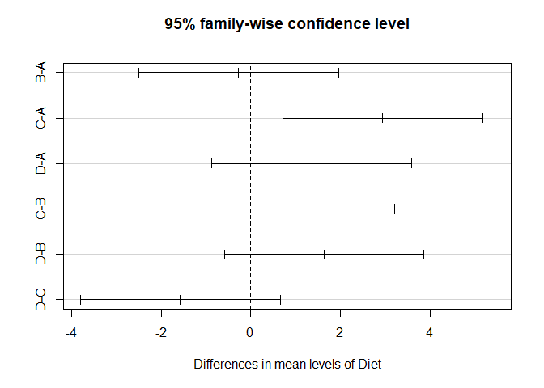

```r
plot(TukeyHSD(ANOVA1))
```

#### Chi-square Test + Fisher’s Exact Test

Chi-square tests for independence are appropriate for testing independence between two categorical variables. Import and attach dataset:

```r
(LungCapData <- read_tsv("LungCapData.txt"))
```

```
## # A tibble: 725 x 6
##    LungCap   Age Height Smoke Gender Caesarean
##      <dbl> <dbl>  <dbl> <chr> <chr>  <chr>
##  1    6.48     6   62.1 no    male   no
##  2   10.1     18   74.7 yes   female no
##  3    9.55    16   69.7 no    female yes
##  4   11.1     14   71   no    male   no
##  5    4.8      5   56.9 no    male   no
##  6    6.22    11   58.7 no    female no
##  7    4.95     8   63.3 no    male   yes
##  8    7.32    11   70.4 no    male   no
##  9    8.88    15   70.5 no    male   no
## 10    6.8     11   59.2 no    male   no
## # ... with 715 more rows
```

```r
attach(LungCapData)
```

`chisq.test` is the command used to perform the chi-squared test. Before performing the test, we need to construct a contingency table.

```r
(TAB <- table(Gender, Smoke))
```

```
##         Smoke
## Gender    no yes
##   female 314  44
##   male   334  33
```

Next, execute the test on the contingency table.

```r
(CHI <- chisq.test(TAB, correct = T))
```

```
##
##  Pearson's Chi-squared test with Yates' continuity correction
##
## data:  TAB
## X-squared = 1.7443, df = 1, p-value = 0.1866
```

As with other tests, we can store results in an object and extract attributes using `attributes`:

```r
attributes(CHI)
```

```
## $names
## [1] "statistic" "parameter" "p.value"   "method"    "data.name" "observed"
## [7] "expected"  "residuals" "stdres"
##
## $class
## [1] "htest"
```

```r
CHI$expected
```

```
##         Smoke
## Gender         no      yes
##   female 319.9779 38.02207
##   male   328.0221 38.97793
```

If the assumptions of the Chi-square test are not met, then we might perform a Fisher’s Exact Test (a non-parametric Chi-square test). Use the `fisher.test` command.

```r
fisher.test(TAB, conf.int = T, conf.level = 0.95)
```

```
##
##  Fisher's Exact Test for Count Data
##
## data:  TAB
## p-value = 0.1845
## alternative hypothesis: true odds ratio is not equal to 1
## 95 percent confidence interval:
##  0.4233701 1.1659426
## sample estimates:
## odds ratio
##  0.7054345
```